# HR_DATASET_ATTRITION_PREDICTION

```python
import pyforest

import matplotlib.pyplot as plt
import warnings
warnings.filterwarnings('ignore')
```

```python
df = pd.read_csv('HR_DATASET.csv')
df.head()
```

|  | Age | Attrition | BusinessTravel | DailyRate | Department | DistanceFromHome | Education | EducationField | EmployeeCount | EmployeeNumber | ... | RelationshipSatisfaction | StandardHours | StockOptionLevel | TotalWorkingYears | TrainingTimesLastYear | WorkLifeBalance | YearsAtCompany | YearsInCurrentRole | YearsSinceLastPromotion | YearsWithCurrManager |
| --- | --- | --- | --- | --- | --- | --- | --- | --- | --- | --- | --- | --- | --- | --- | --- | --- | --- | --- | --- | --- | --- |
| 0 | 41 | Yes | Travel_Rarely | 1102 | Sales | 1 | 2 | Life Sciences | 1 | 1 | ... | 1 | 80 | 0 | 8 | 0 | 1 | 6 | 4 | 0 | 5 |
| 1 | 49 | No | Travel_Frequently | 279 | Research & Development | 8 | 1 | Life Sciences | 1 | 2 | ... | 4 | 80 | 1 | 10 | 3 | 3 | 10 | 7 | 1 | 7 |
| 2 | 37 | Yes | Travel_Rarely | 1373 | Research & Development | 2 | 2 | Other | 1 | 4 | ... | 2 | 80 | 0 | 7 | 3 | 3 | 0 | 0 | 0 | 0 |
| 3 | 33 | No | Travel_Frequently | 1392 | Research & Development | 3 | 4 | Life Sciences | 1 | 5 | ... | 3 | 80 | 0 | 8 | 3 | 3 | 8 | 7 | 3 | 0 |
| 4 | 27 | No | Travel_Rarely | 591 | Research & Development | 2 | 1 | Medical | 1 | 7 | ... | 4 | 80 | 1 | 6 | 3 | 3 | 2 | 2 | 2 | 2 |

5 rows × 35 columns

```python
df.shape
```

```
(917, 35)
```

```python
df['Department'].unique()
```

```
array(['Sales', 'Research & Development', 'Human Resources'], dtype=object)
```

```python
df.info()
```

```
<class 'pandas.core.frame.DataFrame'>
RangeIndex: 917 entries, 0 to 916
Data columns (total 35 columns):
 #   Column                    Non-Null Count  Dtype
---  ------                    --------------  -----
 0   Age                       917 non-null    int64
 1   Attrition                 917 non-null    object
 2   BusinessTravel            917 non-null    object
 3   DailyRate                 917 non-null    int64
 4   Department                917 non-null    object
 5   DistanceFromHome          917 non-null    int64
 6   Education                 917 non-null    int64
 7   EducationField            917 non-null    object
 8   EmployeeCount             917 non-null    int64
 9   EmployeeNumber            917 non-null    int64
```

[output cut: 27 more lines]

```python
df.describe()
```

|  | Age | DailyRate | DistanceFromHome | Education | EmployeeCount | EmployeeNumber | EnvironmentSatisfaction | HourlyRate | JobInvolvement | JobLevel | ... | RelationshipSatisfaction | StandardHours | StockOptionLevel | TotalWorkingYears | TrainingTimesLastYear | WorkLifeBalance | YearsAtCompany | YearsInCurrentRole | YearsSinceLastPromotion | YearsWithCurrManager |
| --- | --- | --- | --- | --- | --- | --- | --- | --- | --- | --- | --- | --- | --- | --- | --- | --- | --- | --- | --- | --- | --- |
| count | 917.000000 | 917.000000 | 917.000000 | 917.000000 | 917.0 | 917.000000 | 917.000000 | 917.000000 | 917.000000 | 917.000000 | ... | 917.000000 | 917.0 | 917.000000 | 917.000000 | 917.000000 | 917.000000 | 917.000000 | 917.000000 | 917.000000 | 917.000000 |
| mean | 36.938931 | 785.711014 | 9.294438 | 2.921483 | 1.0 | 1413.466739 | 2.738277 | 66.231189 | 2.721919 | 2.044711 | ... | 2.637950 | 80.0 | 0.821156 | 11.179935 | 2.791712 | 2.760087 | 6.972737 | 4.217012 | 2.147219 | 4.062159 |
| std | 8.984981 | 401.902148 | 8.092566 | 1.020717 | 0.0 | 388.606884 | 1.103382 | 20.237536 | 0.720936 | 1.100400 | ... | 1.078673 | 0.0 | 0.864555 | 7.802790 | 1.292917 | 0.708047 | 5.951250 | 3.588223 | 3.176250 | 3.571395 |
| min | 18.000000 | 102.000000 | 1.000000 | 1.000000 | 1.0 | 1.000000 | 1.000000 | 30.000000 | 1.000000 | 1.000000 | ... | 1.000000 | 80.0 | 0.000000 | 0.000000 | 0.000000 | 1.000000 | 0.000000 | 0.000000 | 0.000000 | 0.000000 |
| 25% | 30.000000 | 444.000000 | 2.000000 | 2.000000 | 1.0 | 1084.000000 | 2.000000 | 49.000000 | 2.000000 | 1.000000 | ... | 2.000000 | 80.0 | 0.000000 | 6.000000 | 2.000000 | 2.000000 | 3.000000 | 2.000000 | 0.000000 | 2.000000 |
| 50% | 36.000000 | 772.000000 | 7.000000 | 3.000000 | 1.0 | 1425.000000 | 3.000000 | 66.000000 | 3.000000 | 2.000000 | ... | 3.000000 | 80.0 | 1.000000 | 10.000000 | 3.000000 | 3.000000 | 5.000000 | 3.000000 | 1.000000 | 3.000000 |
| 75% | 43.000000 | 1141.000000 | 14.000000 | 4.000000 | 1.0 | 1737.000000 | 4.000000 | 84.000000 | 3.000000 | 3.000000 | ... | 4.000000 | 80.0 | 1.000000 | 15.000000 | 3.000000 | 3.000000 | 9.000000 | 7.000000 | 3.000000 | 7.000000 |
| max | 60.000000 | 1498.000000 | 29.000000 | 5.000000 | 1.0 | 2068.000000 | 4.000000 | 100.000000 | 4.000000 | 5.000000 | ... | 4.000000 | 80.0 | 3.000000 | 40.000000 | 6.000000 | 4.000000 | 36.000000 | 17.000000 | 15.000000 | 17.000000 |

8 rows × 26 columns

```python
df.drop(['EmployeeNumber','EmployeeCount'], axis=1, inplace=True)
```

```python
df.columns
```

```
Index(['Age', 'Attrition', 'BusinessTravel', 'DailyRate', 'Department',
       'DistanceFromHome', 'Education', 'EducationField',
       'EnvironmentSatisfaction', 'Gender', 'HourlyRate', 'JobInvolvement',
       'JobLevel', 'JobRole', 'JobSatisfaction', 'MaritalStatus',
       'MonthlyIncome', 'MonthlyRate', 'NumCompaniesWorked', 'Over18',
       'OverTime', 'PercentSalaryHike', 'PerformanceRating',
       'RelationshipSatisfaction', 'StandardHours', 'StockOptionLevel',
       'TotalWorkingYears', 'TrainingTimesLastYear', 'WorkLifeBalance',
       'YearsAtCompany', 'YearsInCurrentRole', 'YearsSinceLastPromotion',
       'YearsWithCurrManager'],
      dtype='object')
```

```python
# Exploratory data analysis
```

```python
# define numerical & categorical columns
numeric_features = [feature for feature in df.columns if df[feature].dtype != 'O']
categorical_features = [feature for feature in df.columns if df[feature].dtype == 'O']

# print columns
print('We have {} numerical features : {}'.format(len(numeric_features), numeric_features))
print('\nWe have {} categorical features : {}'.format(len(categorical_features), categorical_features))
```

```
We have 24 numerical features : ['Age', 'DailyRate', 'DistanceFromHome', 'Education', 'EnvironmentSatisfaction', 'HourlyRate', 'JobInvolvement', 'JobLevel', 'JobSatisfaction', 'MonthlyIncome', 'MonthlyRate', 'NumCompaniesWorked', 'PercentSalaryHike', 'PerformanceRating', 'RelationshipSatisfaction', …

We have 9 categorical features : ['Attrition', 'BusinessTravel', 'Department', 'EducationField', 'Gender', 'JobRole', 'MaritalStatus', 'Over18', 'OverTime']
```

```python
# proportion of count data on categorical columns
for col in categorical_features:
    print(df[col].value_counts(normalize=True) * 100)
    print('---------------------------')
```

```
No     83.206107
Yes    16.793893
Name: Attrition, dtype: float64
---------------------------
Travel_Rarely        70.665213
Travel_Frequently    18.756816
Non-Travel           10.577972
Name: BusinessTravel, dtype: float64
---------------------------
Research & Development    65.103599
Sales                     29.989095
Human Resources            4.907306
Name: Department, dtype: float64
---------------------------
Life Sciences       41.984733
Medical             31.079607
Marketing           10.032715
Technical Degree     8.942203
Other                5.997819
Human Resources      1.962923
Name: EducationField, dtype: float64
---------------------------
Male      59.97819
Female    40.02181
Name: Gender, dtype: float64
---------------------------
Sales Executive              22.137405
Research Scientist           19.847328
Laboratory Technician        17.666303
Manufacturing Director       10.032715
Healthcare Representative     9.051254
Manager                       6.324973
Sales Representative          5.452563
Research Director             5.234460
Human Resources               4.252999
Name: JobRole, dtype: float64
---------------------------
Married     47.546347
Single      31.297710
Divorced    21.155943
Name: MaritalStatus, dtype: float64
---------------------------
Y    100.0
Name: Over18, dtype: float64
---------------------------
No     71.537623
Yes    28.462377
Name: OverTime, dtype: float64
---------------------------
```

### Insights

- Column Attrition is biased towards No means less number of people is leaving the company.
- Column Over18 has no significance because all the values are Y hence it should be dropped.
- Column Overtime is biased towards No means there are less people working overtime.

## Univariate Analysis

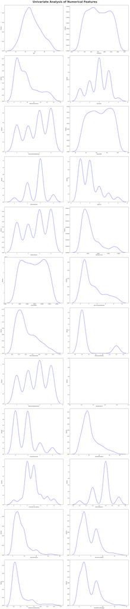

```python
plt.figure(figsize=(20, 100))
plt.suptitle('Univariate Analysis of Numerical Features', fontsize=30, fontweight='bold', alpha=0.8, y=1.)

for i in range(0, len(numeric_features)):
    plt.subplot(13, 2, i+1)
    sns.kdeplot(x=df[numeric_features[i]], color='blue')
    plt.xlabel(numeric_features[i])
    plt.tight_layout()


plt.show()
```

```python
categorical_features.remove("Over18")
```

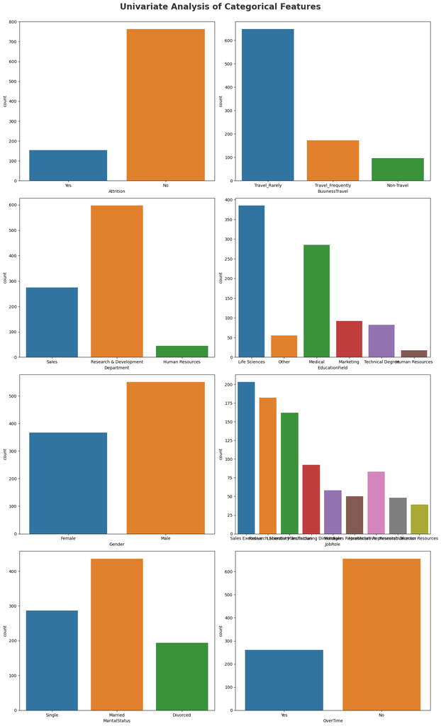

```python
plt.figure(figsize=(15, 30))
plt.suptitle('Univariate Analysis of Categorical Features', fontsize=20, fontweight='bold', alpha=0.8, y=1.)

for i in range(0, len(categorical_features)):
    plt.subplot(5, 2, i+1)
    sns.countplot(x=df[categorical_features[i]])
    plt.xlabel(categorical_features[i])
    plt.tight_layout()

plt.show()
```

```python
# Missing value treatment
```

```python
df.isnull().sum()
```

```
Age                         0
Attrition                   0
BusinessTravel              0
DailyRate                   0
Department                  0
DistanceFromHome            0
Education                   0
EducationField              0
EnvironmentSatisfaction     0
Gender                      0
HourlyRate                  0
JobInvolvement              0
JobLevel                    0
JobRole                     0
JobSatisfaction             0
MaritalStatus               0
MonthlyIncome               0
MonthlyRate                 0
NumCompaniesWorked          0
Over18                      0
OverTime                    0
PercentSalaryHike           0
PerformanceRating           0
RelationshipSatisfaction    0
StandardHours               0
StockOptionLevel            0
TotalWorkingYears           0
TrainingTimesLastYear       0
WorkLifeBalance             0
YearsAtCompany              0
YearsInCurrentRole          0
YearsSinceLastPromotion     0
YearsWithCurrManager        0
dtype: int64
```

```python
#duplicated values
df.duplicated().sum()
```

```
0
```

```python
# Outlier Analysis
```

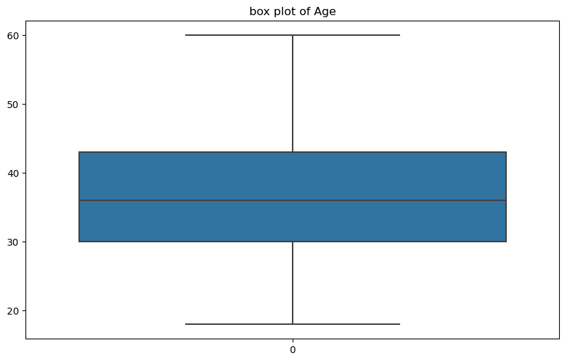

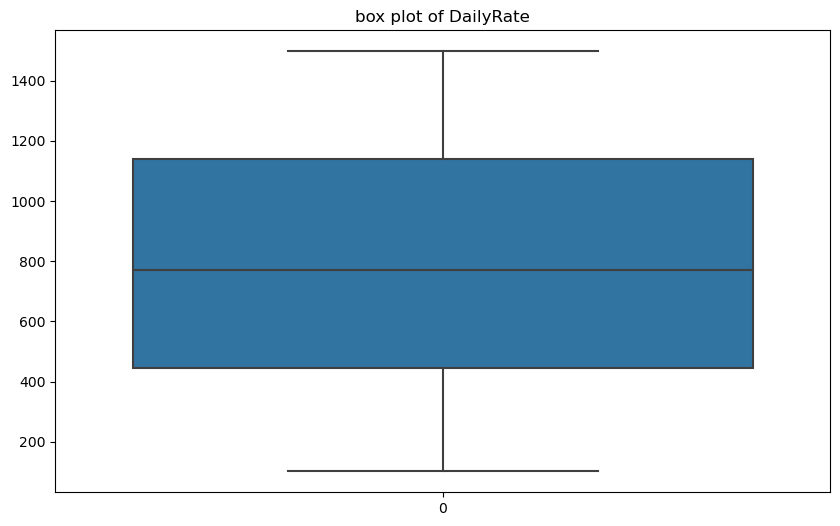

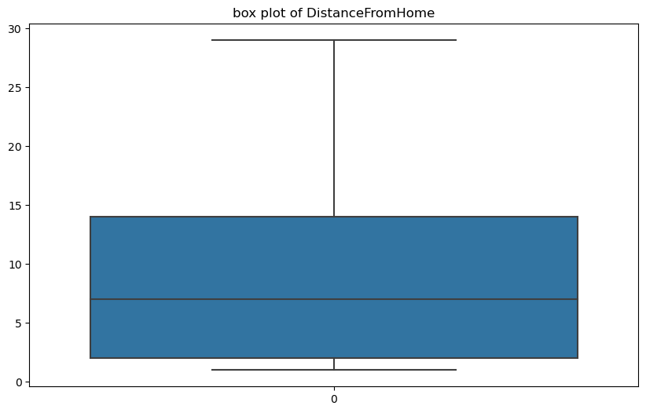

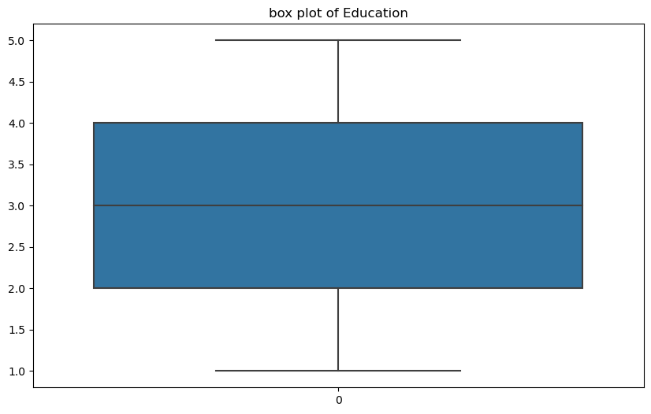

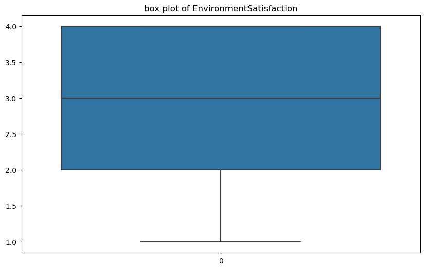

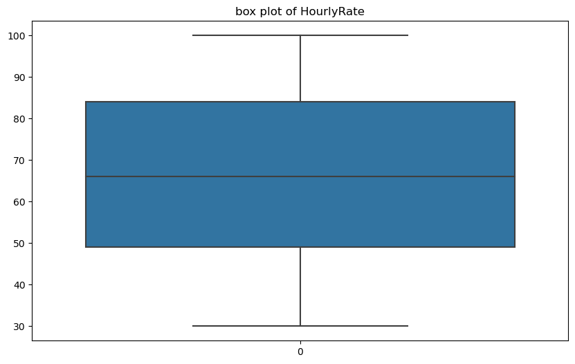

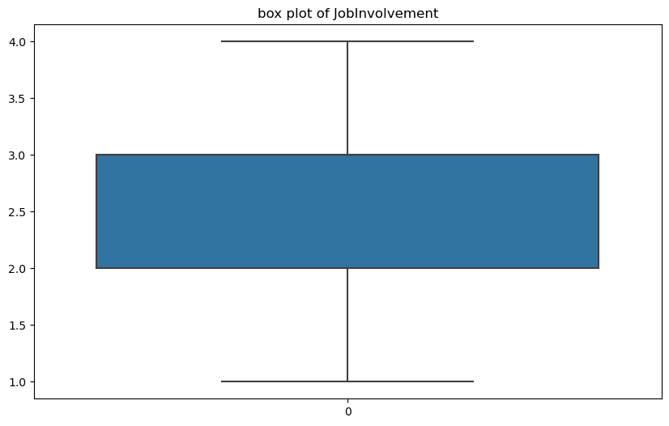

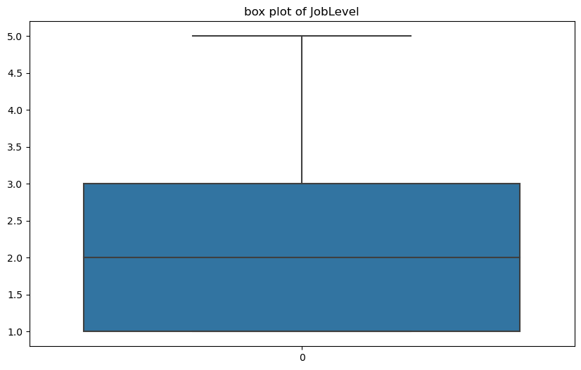

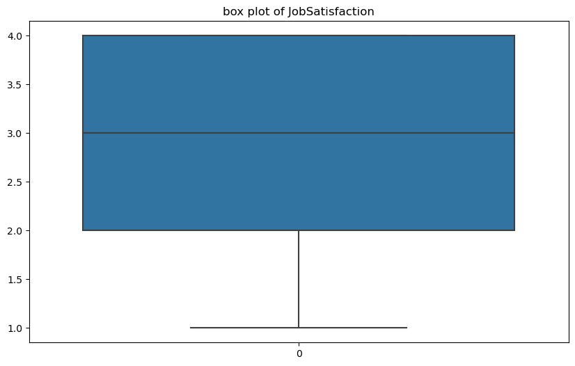

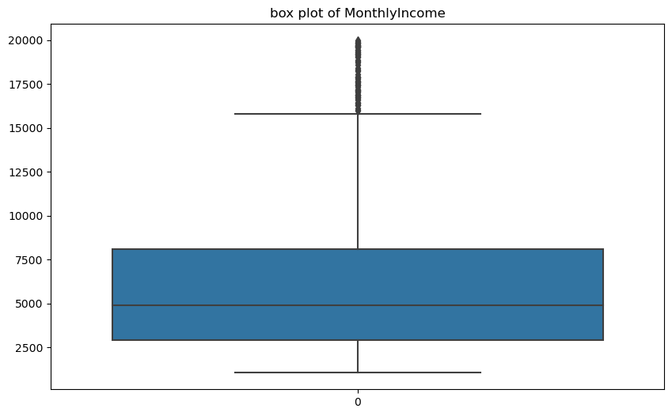

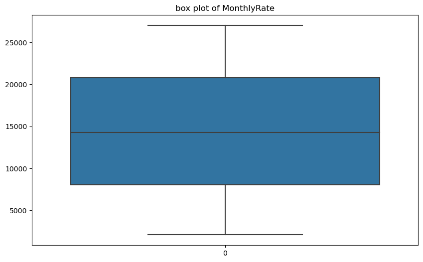

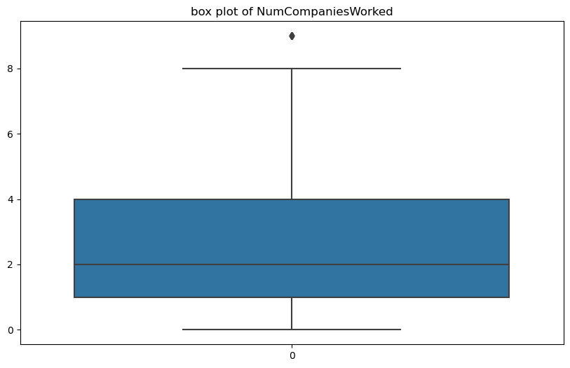

[12 more figures not shown]

```python
ColsBox = df.select_dtypes('int64')
for col in ColsBox.columns:
    plt.figure(figsize=(10,6))
    plt.title('box plot of '+col)
    sns.boxplot(df[col])

plt.show()
```

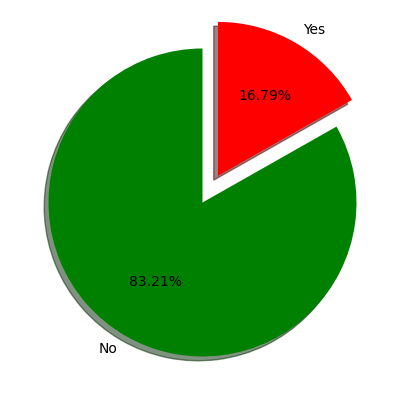

```python
# Target variable visualization
percentage = df.Attrition.value_counts(normalize=True)*100
labels = ["No","Yes"]

# Plot PieChart with Ploty library
fig, ax = plt.subplots(figsize =(5, 5))
explode = (0, 0.2)
ax.pie(percentage, labels = labels, startangle = 90,
       autopct='%1.2f%%',explode=explode, shadow=True, colors='greens')
plt.show()
```

```python
df['Attrition'].value_counts()
```

```
No     763
Yes    154
Name: Attrition, dtype: int64
```

```python
# Analysis of target variable with independent variables
```

```python
df.groupby('Age')['Attrition'].value_counts(normalize=True).to_frame()*100
```

| Age | Attrition | Attrition |
| --- | --- | --- |
| 18 | No | 60.0 |
|  | Yes | 40.0 |
| 19 | No | 50.0 |
|  | Yes | 50.0 |
| 20 | No | 50.0 |
| ... | ... | ... |
| 57 | No | 100.0 |
| 58 | No | 60.0 |
|  | Yes | 40.0 |
| 59 | No | 100.0 |
| 60 | No | 100.0 |

82 rows × 1 columns

```python
df2 = df.copy()
```

[output not shown]

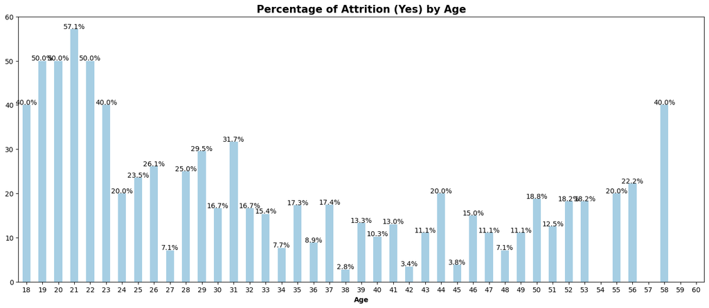

```python
# Age and Attrition
plt.figure(figsize=[18,7])

(df2[df2["Attrition"] == 'Yes']['Age'].value_counts() * 100 / df2['Age'].value_counts()).plot(
    kind='bar', stacked=True, colormap='Paired')
plt.title("Percentage of Attrition (Yes) by Age", fontsize=15, fontweight='bold')
order1 = (100 * df2[df2["Attrition"] == 'Yes']['Age'].value_counts() / df2['Age'].value_counts())
for n in range(order1.shape[0]):
    count = order1.iloc[n]
    strt = '{:0.1f}%'.format(count)
    plt.text(n, count + 0.1, strt, ha='center')

plt.xlabel('Age', fontweight='bold')
plt.xticks(rotation=0)
plt.show()
```

As per visualization, age group from 18 to 23 have highest rate of 'Attrition'.

```python
df.groupby('BusinessTravel')['Attrition'].value_counts(normalize=True).to_frame()*100
```

| BusinessTravel | Attrition | Attrition |
| --- | --- | --- |
| Non-Travel | No | 90.721649 |
|  | Yes | 9.278351 |
| Travel_Frequently | No | 74.418605 |
|  | Yes | 25.581395 |
| Travel_Rarely | No | 84.413580 |
|  | Yes | 15.586420 |

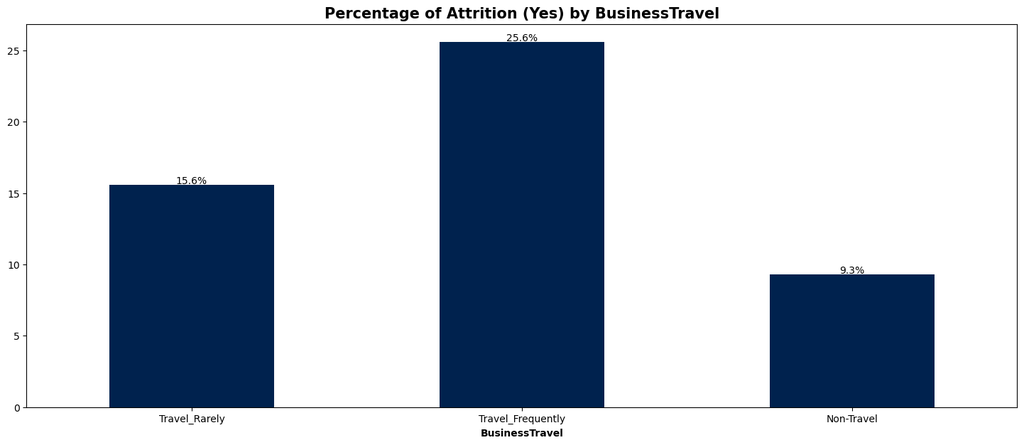

```python
# Business Travel and Attrition
plt.figure(figsize=[18,7])

(df2[df2["Attrition"] == 'Yes']['BusinessTravel'].value_counts() * 100 / df2['BusinessTravel'].value_counts()).plot(
    kind='bar', stacked=True, colormap='cividis')
plt.title("Percentage of Attrition (Yes) by BusinessTravel", fontsize=15, fontweight='bold')
order1 = (100 * df2[df2["Attrition"] == 'Yes']['BusinessTravel'].value_counts() / df2['BusinessTravel'].value_counts())
for n in range(order1.shape[0]):
    count = order1.iloc[n]
    strt = '{:0.1f}%'.format(count)
    plt.text(n, count + 0.1, strt, ha='center')

plt.xlabel('BusinessTravel', fontweight='bold')
plt.xticks(rotation=0)
plt.show()
```

#### Interpretation:

The employees who travel frequenlty having higher attrition percentage.

```python
df.groupby('Department')['Attrition'].value_counts(normalize=True).to_frame()*100
```

| Department | Attrition | Attrition |
| --- | --- | --- |
| Human Resources | No | 82.222222 |
|  | Yes | 17.777778 |
| Research & Development | No | 85.762144 |
|  | Yes | 14.237856 |
| Sales | No | 77.818182 |
|  | Yes | 22.181818 |

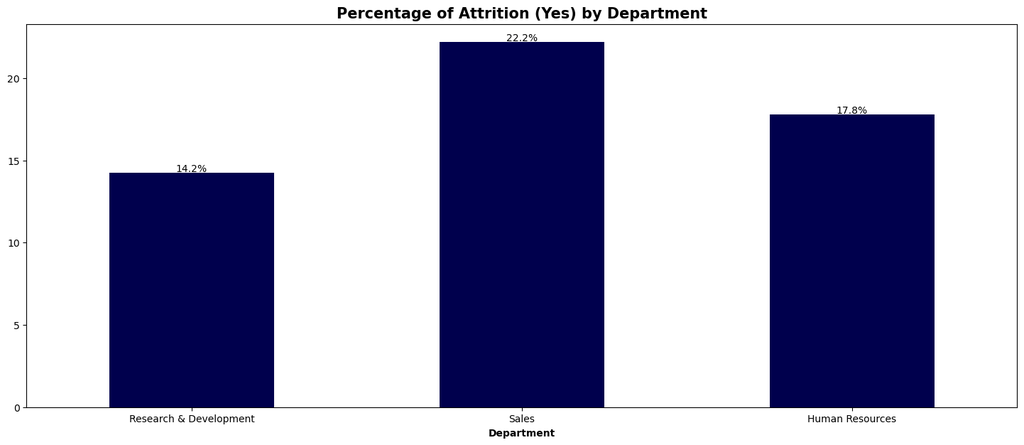

```python
# Department and Attrition
plt.figure(figsize=[18,7])

(df2[df2["Attrition"] == 'Yes']['Department'].value_counts() * 100 / df2['Department'].value_counts()).plot(
    kind='bar', stacked=True, colormap='seismic')
plt.title("Percentage of Attrition (Yes) by Department", fontsize=15, fontweight='bold')
order1 = (100 * df2[df2["Attrition"] == 'Yes']['Department'].value_counts() / df2['Department'].value_counts())
for n in range(order1.shape[0]):
    count = order1.iloc[n]
    strt = '{:0.1f}%'.format(count)
    plt.text(n, count + 0.1, strt, ha='center')

plt.xlabel('Department', fontweight='bold')
plt.xticks(rotation=0)
plt.show()
```

#### Interpretation:

The employees working in the Sales Department having higher Attrition percentage.

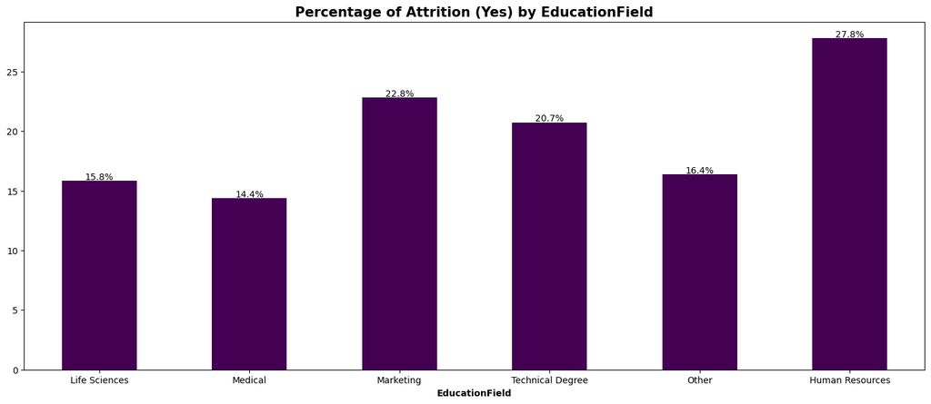

```python
# EducationField and Attrition
plt.figure(figsize=[18,7])

(df2[df2["Attrition"] == 'Yes']['EducationField'].value_counts() * 100 / df2['EducationField'].value_counts()).plot(
    kind='bar', stacked=True, colormap='viridis')
plt.title("Percentage of Attrition (Yes) by EducationField", fontsize=15, fontweight='bold')
order1 = (100 * df2[df2["Attrition"] == 'Yes']['EducationField'].value_counts() / df2['EducationField'].value_counts())
for n in range(order1.shape[0]):
    count = order1.iloc[n]
    strt = '{:0.1f}%'.format(count)
    plt.text(n, count + 0.1, strt, ha='center')

plt.xlabel('EducationField', fontweight='bold')
plt.xticks(rotation=0)
plt.show()
```

#### Interpretation:

The employees from Human Resources Education Field having higher Attrition percentage.

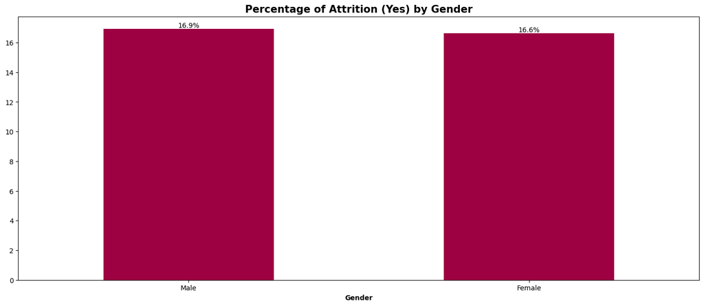

```python
# Gender and Attrition
plt.figure(figsize=[18,7])

(df2[df2["Attrition"] == 'Yes']['Gender'].value_counts() * 100 / df2['Gender'].value_counts()).plot(
    kind='bar', stacked=True, colormap='Spectral')
plt.title("Percentage of Attrition (Yes) by Gender", fontsize=15, fontweight='bold')
order1 = (100 * df2[df2["Attrition"] == 'Yes']['Gender'].value_counts() / df2['Gender'].value_counts())
for n in range(order1.shape[0]):
    count = order1.iloc[n]
    strt = '{:0.1f}%'.format(count)
    plt.text(n, count + 0.1, strt, ha='center')

plt.xlabel('Gender', fontweight='bold')
plt.xticks(rotation=0)
plt.show()
```

#### Interpretation:

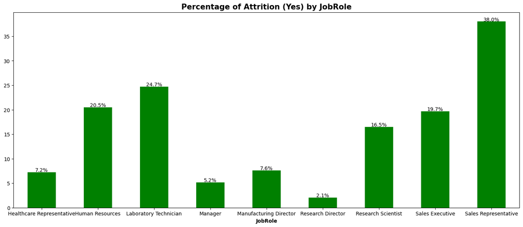

```python
# Job role and Attrition
plt.figure(figsize=[18,7])

(df2[df2["Attrition"] == 'Yes']['JobRole'].value_counts() * 100 / df2['JobRole'].value_counts()).plot(
    kind='bar', stacked=True, colormap='ocean')
plt.title("Percentage of Attrition (Yes) by JobRole", fontsize=15, fontweight='bold')
order1 = (100 * df2[df2["Attrition"] == 'Yes']['JobRole'].value_counts() / df2['JobRole'].value_counts())
for n in range(order1.shape[0]):
    count = order1.iloc[n]
    strt = '{:0.1f}%'.format(count)
    plt.text(n, count + 0.1, strt, ha='center')

plt.xlabel('JobRole', fontweight='bold')
plt.xticks(rotation=0)
plt.show()
```

#### Interpretation:

The employees who are performing Sales Representative Job Role having higher Attrition rate.

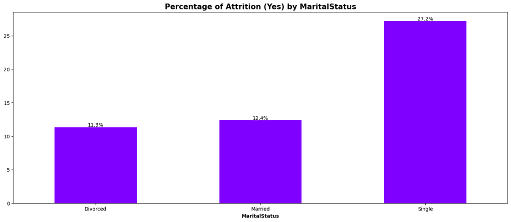

```python
# MaritalStatus and Attrition
plt.figure(figsize=[18,7])

(df2[df2["Attrition"] == 'Yes']['MaritalStatus'].value_counts() * 100 / df2['MaritalStatus'].value_counts()).plot(
    kind='bar', stacked=True, colormap='rainbow')
plt.title("Percentage of Attrition (Yes) by MaritalStatus", fontsize=15, fontweight='bold')
order1 = (100 * df2[df2["Attrition"] == 'Yes']['MaritalStatus'].value_counts() / df2['MaritalStatus'].value_counts())
for n in range(order1.shape[0]):
    count = order1.iloc[n]
    strt = '{:0.1f}%'.format(count)
    plt.text(n, count + 0.1, strt, ha='center')

plt.xlabel('MaritalStatus', fontweight='bold')
plt.xticks(rotation=0)
plt.show()
```

#### Interpretation:

The employees having single Marital Status are highly leaving the company.

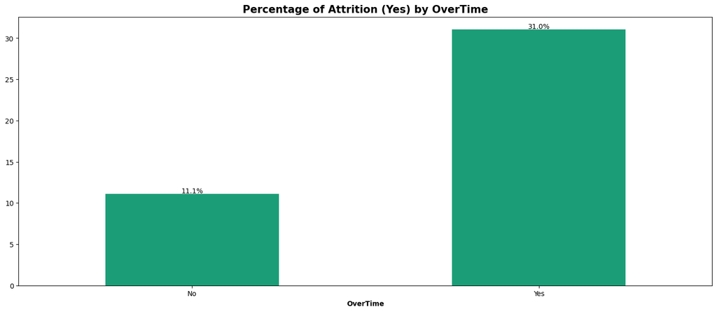

```python
# Overtime and Attrition
plt.figure(figsize=[18,7])

(df2[df2["Attrition"] == 'Yes']['OverTime'].value_counts() * 100 / df2['OverTime'].value_counts()).plot(
    kind='bar', stacked=True, colormap='Dark2')
plt.title("Percentage of Attrition (Yes) by OverTime", fontsize=15, fontweight='bold')
order1 = (100 * df2[df2["Attrition"] == 'Yes']['OverTime'].value_counts() / df2['OverTime'].value_counts())
for n in range(order1.shape[0]):
    count = order1.iloc[n]
    strt = '{:0.1f}%'.format(count)
    plt.text(n, count + 0.1, strt, ha='center')

plt.xlabel('OverTime', fontweight='bold')
plt.xticks(rotation=0)
plt.show()
```

### Interpretation:

Column Overtime is biased towards No means there are less people working overtime.

```python
#Dropping the columns
df.drop(columns=['Over18'] , inplace = True)
```

```python
from sklearn.preprocessing import MinMaxScaler

encoder = LabelEncoder()
df['EducationField'] = encoder.fit_transform(df['EducationField'])
df['Gender'] = encoder.fit_transform(df['Gender'])
df['JobRole'] = encoder.fit_transform(df['JobRole'])
df['MaritalStatus'] = encoder.fit_transform(df['MaritalStatus'])
df['OverTime'] = encoder.fit_transform(df['OverTime'])
```

```python
df['BusinessTravel'] = df['BusinessTravel'].replace({'Travel_Rarely':0 ,'Travel_Frequently':1 , 'Non-Travel':3})
df['BusinessTravel'] = df['BusinessTravel'].astype('int64')
```

```python
df['Department'] = df['Department'].replace({'Research & Development':0 ,'Sales':1 , 'Human Resources':3})
df['Department'] = df['Department'].astype('int64')
```

```python
df['Attrition'] = df['Attrition'].replace({'Yes':1 , 'No':0})
```

```python
scaler = MinMaxScaler()
df[df.columns] = scaler.fit_transform(df[df.columns])
```

```python
# Input variables and target variables
X = df.drop('Attrition', axis=1)
y = df['Attrition']
```

```python
# Train Test splitting of the data
from sklearn.model_selection import train_test_split
X_train, X_test, y_train, y_test = train_test_split(X, y,test_size=0.2, random_state=42)
X_train.shape, X_test.shape
```

```
((733, 31), (184, 31))
```

```python
from sklearn.ensemble import RandomForestClassifier, GradientBoostingClassifier
from sklearn.linear_model import LogisticRegression
from sklearn.neighbors import KNeighborsClassifier
from sklearn.tree import DecisionTreeClassifier
from sklearn.svm import SVC
from sklearn.metrics import accuracy_score, classification_report,ConfusionMatrixDisplay, \
                            precision_score, recall_score, f1_score,fbeta_score, roc_auc_score,roc_curve
from sklearn.naive_bayes import GaussianNB
from imblearn.over_sampling import SMOTE
```

```python
models = {
    "Decision Tree": DecisionTreeClassifier(),
    "Random Forest": RandomForestClassifier(),
    "Logistic Regression": LogisticRegression(),
    "SVM": SVC(),
    "KNN": KNeighborsClassifier(),
    "Gradient Boosting": GradientBoostingClassifier(),
    "Naive Bayes": GaussianNB()
}
```

```python
def evaluate_clf(true, predicted):
    acc = accuracy_score(true, predicted) # Calculate Accuracy
    f1 = f1_score(true, predicted) # Calculate F1-score
    precision = precision_score(true, predicted) # Calculate Precision
    recall = recall_score(true, predicted)  # Calculate Recall
    roc_auc = roc_auc_score(true, predicted) #Calculate Roc
    return acc, f1 , precision, recall, roc_auc
```

```python
def evaluate_models(X, y, models):
    '''
    This function takes in X and y and models dictionary as input
    It splits the data into Train Test split
    Iterates through the given model dictionary and evaluates the metrics
    Returns: Dataframe which contains report of all models metrics with cost
    '''
    # separate dataset into train and test
    X_train, X_test, y_train, y_test = train_test_split(X,y,test_size=0.2,random_state=42)

    models_list = []
    accuracy_list = []
    auc= []

    for i in range(len(list(models))):
        model = list(models.values())[i]
        model.fit(X_train, y_train) # Train model

        # Make predictions
        y_train_pred = model.predict(X_train)
        y_test_pred = model.predict(X_test)

        # Training set performance
        model_train_accuracy, model_train_f1,model_train_precision,\
        model_train_recall,model_train_rocauc_score=evaluate_clf(y_train ,y_train_pred)


        # Test set performance
        model_test_accuracy,model_test_f1,model_test_precision,\
        model_test_recall,model_test_rocauc_score=evaluate_clf(y_test, y_test_pred)

        print(list(models.keys())[i])
        models_list.append(list(models.keys())[i])

        print('Model performance for Training set')
        print("- Accuracy: {:.4f}".format(model_train_accuracy))
        print('- F1 score: {:.4f}'.format(model_train_f1))
        print('- Precision: {:.4f}'.format(model_train_precision))
        print('- Recall: {:.4f}'.format(model_train_recall))
        print('- Roc Auc Score: {:.4f}'.format(model_train_rocauc_score))

        print('----------------------------------')

        print('Model performance for Test set')
        print('- Accuracy: {:.4f}'.format(model_test_accuracy))
        accuracy_list.append(model_test_accuracy)
        print('- F1 score: {:.4f}'.format(model_test_f1))
        print('- Precision: {:.4f}'.format(model_test_precision))
        print('- Recall: {:.4f}'.format(model_test_recall))
        print('- Roc Auc Score: {:.4f}'.format(model_test_rocauc_score))
        auc.append(model_test_rocauc_score)
        print('='*35)
        print('\n')

    report=pd.DataFrame(list(zip(models_list, accuracy_list)), columns=['Model Name', 'Accuracy']).sort_values(by=['Accuracy'], ascending=False)

    return report
```

```python
base_model_report = evaluate_models(X, y, models=models)
```

```
Decision Tree
Model performance for Training set
- Accuracy: 1.0000
- F1 score: 1.0000
- Precision: 1.0000
- Recall: 1.0000
- Roc Auc Score: 1.0000
----------------------------------
Model performance for Test set
- Accuracy: 0.8043
- F1 score: 0.4194
- Precision: 0.4333
- Recall: 0.4062
- Roc Auc Score: 0.6472
===================================


Random Forest
Model performance for Training set
- Accuracy: 1.0000
- F1 score: 1.0000
- Precision: 1.0000
- Recall: 1.0000
- Roc Auc Score: 1.0000
----------------------------------
Model performance for Test set
- Accuracy: 0.8261
- F1 score: 0.2000
- Precision: 0.5000
- Recall: 0.1250
- Roc Auc Score: 0.5493
===================================


Logistic Regression
Model performance for Training set
- Accuracy: 0.8731
- F1 score: 0.4431
- Precision: 0.8222
- Recall: 0.3033
```

[output cut: 62 more lines]

```
Naive Bayes
Model performance for Training set
- Accuracy: 0.8417
- F1 score: 0.5433
- Precision: 0.5227
- Recall: 0.5656
- Roc Auc Score: 0.7312
----------------------------------
Model performance for Test set
- Accuracy: 0.7989
- F1 score: 0.5195
- Precision: 0.4444
- Recall: 0.6250
- Roc Auc Score: 0.7303
===================================
```

```python
tuned_paramaters = [{'criterion': ['entropy', 'gini'],
                     'max_depth': range(2, 10),
                     'max_features': ["sqrt", "log2"],
                     'min_samples_split': range(2,10),
                     'min_samples_leaf': range(1,10),
                     'max_leaf_nodes': range(1, 10)}]
```

```python
models = {
    "Decision Tree": DecisionTreeClassifier(),
    "Random Forest": RandomForestClassifier(),
    "Logistic Regression": LogisticRegression(),
    "SVM": SVC(),
    "KNN": KNeighborsClassifier(),
    "Gradient Boosting": GradientBoostingClassifier(),
    "Naive Bayes": GaussianNB()
}
```

```python
def evaluate_models(X, y, models):
    '''
    This function takes in X and y and models dictionary as input
    It splits the data into Train Test split
    Iterates through the given model dictionary and evaluates the metrics
    Returns: Dataframe which contains report of all models metrics with cost
    '''
    # separate dataset into train and test
    X_train, X_test, y_train, y_test = train_test_split(X,y,test_size=0.2,random_state=42)

    models_list = []
    accuracy_list = []
    auc= []

    for i in range(len(list(models))):
        model = list(models.values())[i]
        model.fit(X_train, y_train) # Train model

        # Make predictions
        y_train_pred = model.predict(X_train)
        y_test_pred = model.predict(X_test)

        # Training set performance
        model_train_accuracy, model_train_f1,model_train_precision,\
        model_train_recall,model_train_rocauc_score=evaluate_clf(y_train ,y_train_pred)


        # Test set performance
        model_test_accuracy,model_test_f1,model_test_precision,\
        model_test_recall,model_test_rocauc_score=evaluate_clf(y_test, y_test_pred)

        print(list(models.keys())[i])
        models_list.append(list(models.keys())[i])

        print('Model performance for Training set')
        print("- Accuracy: {:.4f}".format(model_train_accuracy))
        print('- F1 score: {:.4f}'.format(model_train_f1))
        print('- Precision: {:.4f}'.format(model_train_precision))
        print('- Recall: {:.4f}'.format(model_train_recall))
        print('- Roc Auc Score: {:.4f}'.format(model_train_rocauc_score))

        print('----------------------------------')

        print('Model performance for Test set')
        print('- Accuracy: {:.4f}'.format(model_test_accuracy))
        accuracy_list.append(model_test_accuracy)
        print('- F1 score: {:.4f}'.format(model_test_f1))
        print('- Precision: {:.4f}'.format(model_test_precision))
        print('- Recall: {:.4f}'.format(model_test_recall))
        print('- Roc Auc Score: {:.4f}'.format(model_test_rocauc_score))
        auc.append(model_test_rocauc_score)
        print('='*35)
        print('\n')

    report=pd.DataFrame(list(zip(models_list, accuracy_list)), columns=['Model Name', 'Accuracy']).sort_values(by=['Accuracy'], ascending=False)

    return report
```

```python
base_model_report =evaluate_models(X, y, models=models)
```

```
Decision Tree
Model performance for Training set
- Accuracy: 1.0000
- F1 score: 1.0000
- Precision: 1.0000
- Recall: 1.0000
- Roc Auc Score: 1.0000
----------------------------------
Model performance for Test set
- Accuracy: 0.7826
- F1 score: 0.3103
- Precision: 0.3462
- Recall: 0.2812
- Roc Auc Score: 0.5847
===================================


Random Forest
Model performance for Training set
- Accuracy: 1.0000
- F1 score: 1.0000
- Precision: 1.0000
- Recall: 1.0000
- Roc Auc Score: 1.0000
----------------------------------
Model performance for Test set
- Accuracy: 0.8207
- F1 score: 0.1951
- Precision: 0.4444
- Recall: 0.1250
- Roc Auc Score: 0.5461
===================================


Logistic Regression
Model performance for Training set
- Accuracy: 0.8731
- F1 score: 0.4431
- Precision: 0.8222
- Recall: 0.3033
```

[output cut: 62 more lines]

```
Naive Bayes
Model performance for Training set
- Accuracy: 0.8417
- F1 score: 0.5433
- Precision: 0.5227
- Recall: 0.5656
- Roc Auc Score: 0.7312
----------------------------------
Model performance for Test set
- Accuracy: 0.7989
- F1 score: 0.5195
- Precision: 0.4444
- Recall: 0.6250
- Roc Auc Score: 0.7303
===================================
```

```python
# Using SMOTE
X = df.drop('Attrition', axis=1)
y = df['Attrition']

smote = SMOTE(random_state=42)
X_resampled, y_resampled = smote.fit_resample(X, y)

X_train, X_test, y_train, y_test = train_test_split(X_resampled, y_resampled, test_size=0.2, random_state=60)

rf = RandomForestClassifier()
rf.fit(X_train, y_train)
y_pred = rf.predict(X_test)
```

```python
accuracy = accuracy_score(y_test, y_pred)
acc=accuracy*100
precision = precision_score(y_test, y_pred)
recall = recall_score(y_test, y_pred)
f1 = f1_score(y_test, y_pred)
f2 = fbeta_score(y_test, y_pred, beta=2)

print("Random Forest")
print(f"Accuracy: {accuracy:.4f}")
print(f"Accuracy: {acc:.2f} %")
print(f"Precision: {precision:.2f}")
print(f"Recall: {recall:.2f}")
print(f"F1 Score: {f1:.2f}")
print(f"F2 Score: {f2:.2f}")
```

```
Random Forest
Accuracy: 0.9118
Accuracy: 91.18 %
Precision: 0.93
Recall: 0.89
F1 Score: 0.91
F2 Score: 0.90
```

```python
# Random Forest Classifier parameters
rf_params = {
    "max_depth": [10, 12, None, 15, 20],
    "max_features": ['sqrt', 'log2', None],
    "n_estimators": [10, 50, 100, 200]
}
```

```python
# Using SMOTE
X = df.drop('Attrition', axis=1)
y = df['Attrition']

smote = SMOTE(random_state=42)
X_resampled, y_resampled = smote.fit_resample(X, y)

X_train, X_test, y_train, y_test = train_test_split(X_resampled, y_resampled, test_size=0.2, random_state=60)

rf = RandomForestClassifier()
rf.fit(X_train, y_train)
y_pred = rf.predict(X_test)
```

```python
accuracy = accuracy_score(y_test, y_pred)
acc=accuracy*100
precision = precision_score(y_test, y_pred)
recall = recall_score(y_test, y_pred)
f1 = f1_score(y_test, y_pred)
f2 = fbeta_score(y_test, y_pred, beta=2)

print("Random Forest")
print(f"Accuracy: {accuracy:.4f}")
print(f"Accuracy: {acc:.2f} %")
print(f"Precision: {precision:.2f}")
print(f"Recall: {recall:.2f}")
print(f"F1 Score: {f1:.2f}")
print(f"F2 Score: {f2:.2f}")
```

```
Random Forest
Accuracy: 0.9281
Accuracy: 92.81 %
Precision: 0.93
Recall: 0.93
F1 Score: 0.93
F2 Score: 0.93
```

## #SUGGESTION TO THE ORGANISATION

- Organisation should Conduct regular surveys to assess job satisfaction levels and implement initiatives to improve work-life balance, such as flexible work arrangements, wellness programs, and stress management workshops.
- Provide opportunities for career advancement, skill development, and mentorship programs to motivate employees and increase retention rates.
- Spread positive work environment by promoting effective communication, team-building activities, and initiatives to improve relationship satisfaction among employees.
- Encourage open communication channels for employees to voice their concerns, provide feedback, and participate in decision-making processes. Engaged employees are more likely to stay with the organization.
- Provide targeted support, coaching, and development opportunities to retain valuable talent.